# Capstone 2 / Mission Hospital

Sushil Mendon

2023-04-20

## Import Necessary packages

```r
library(dplyr)
library(mice)
library(janitor)
library(car)
library(caret)
library(Metrics)
library(rpart)
library(rpart.plot)
library(RColorBrewer)
library(rattle)
library(randomForest)
library(ggplot2)
library(corrplot)
library(GGally)
library(readxl)
```

# Import the Dataset

```r
mission_hospital <- read_excel("C:/Users/user/Desktop/Sushil/DABS/Capstone 2/Mission Hospital_Spreadsheet.xlsx",
                   sheet = 3, na = c(""," ", "NA"))

head(mission_hospital)
```

```
## # A tibble: 6 × 24
##     SL.   AGE GENDER `MARITAL STATUS` `KEY COMPLAINTS -CODE` `BODY WEIGHT`
##   <dbl> <dbl> <chr>  <chr>            <chr>                          <dbl>
## 1     1    58 M      MARRIED          other- heart                    49.2
## 2     2    59 M      MARRIED          CAD-DVD                         41
## 3     3    82 M      MARRIED          CAD-TVD                         46.6
## 4     4    46 M      MARRIED          CAD-DVD                         80
## 5     5    60 M      MARRIED          CAD-DVD                         58
## 6     6    75 M      MARRIED          CAD-DVD                         45
## # ℹ 18 more variables: `BODY HEIGHT` <dbl>, `HR PULSE` <dbl>, `BP -HIGH` <dbl>,
## #   `BP-LOW` <chr>, RR <dbl>, `PAST MEDICAL HISTORY CODE` <chr>, HB <dbl>,
## #   UREA <dbl>, CREATININE <dbl>, `MODE OF ARRIVAL` <chr>,
## #   `STATE AT THE TIME OF ARRIVAL` <chr>, `TYPE OF ADMSN` <chr>,
## #   `TOTAL COST TO HOSPITAL` <dbl>, `TOTAL LENGTH OF STAY` <dbl>,
## #   `LENGTH OF STAY - ICU` <dbl>, `LENGTH OF STAY- WARD` <dbl>,
## #   `IMPLANT USED (Y/N)` <chr>, `COST OF IMPLANT` <dbl>
```

```r
str(mission_hospital)
```

```
## tibble [248 × 24] (S3: tbl_df/tbl/data.frame)
##  $ SL.                         : num [1:248] 1 2 3 4 5 6 7 8 9 10 ...
##  $ AGE                         : num [1:248] 58 59 82 46 60 75 73 71 72 61 ...
##  $ GENDER                      : chr [1:248] "M" "M" "M" "M" ...
##  $ MARITAL STATUS              : chr [1:248] "MARRIED" "MARRIED" "MARRIED" "MARRIED" ...
##  $ KEY COMPLAINTS -CODE        : chr [1:248] "other- heart" "CAD-DVD" "CAD-TVD" "CAD-DVD" ...
##  $ BODY WEIGHT                 : num [1:248] 49.2 41 46.6 80 58 45 60 43.8 72 76.6 ...
##  $ BODY HEIGHT                 : num [1:248] 160 155 164 173 175 140 170 164 174 175 ...
##  $ HR PULSE                    : num [1:248] 118 78 100 122 72 130 108 60 95 66 ...
##  $ BP -HIGH                    : num [1:248] 100 70 110 110 180 215 160 130 100 140 ...
##  $ BP-LOW                      : chr [1:248] "80" "50" "80" "80" ...
##  $ RR                          : num [1:248] 32 28 20 24 18 42 24 22 25 22 ...
##  $ PAST MEDICAL HISTORY CODE   : chr [1:248] NA NA "Diabetes2" "hypertension1" ...
##  $ HB                          : num [1:248] 11.4 11.4 11.8 11.8 10 11.8 14.5 10.1 9.6 14 ...
##  $ UREA                        : num [1:248] 33 95 15 74 48 29 31 37 32 15 ...
##  $ CREATININE                  : num [1:248] 0.8 1.7 0.8 1.5 1.9 1 1.6 1.5 1.2 0.4 ...
##  $ MODE OF ARRIVAL             : chr [1:248] "AMBULANCE" "AMBULANCE" "WALKED IN" "AMBULANCE" ...
##  $ STATE AT THE TIME OF ARRIVAL: chr [1:248] "ALERT" "ALERT" "ALERT" "ALERT" ...
##  $ TYPE OF ADMSN               : chr [1:248] "EMERGENCY" "EMERGENCY" "ELECTIVE" "EMERGENCY" ...
##  $ TOTAL COST TO HOSPITAL      : num [1:248] 660293 809130 362231 629990 444876 ...
##  $ TOTAL LENGTH OF STAY        : num [1:248] 25 41 18 14 24 31 15 24 26 20 ...
##  $ LENGTH OF STAY - ICU        : num [1:248] 12 20 9 13 12 9 15 11 9 4 ...
##  $ LENGTH OF STAY- WARD        : num [1:248] 13 21 9 1 12 22 0 13 17 16 ...
##  $ IMPLANT USED (Y/N)          : chr [1:248] "Y" "Y" "N" "Y" ...
##  $ COST OF IMPLANT             : num [1:248] 38000 39690 0 89450 0 ...
```

```r
mission_hospital$`BP-LOW` <- as.numeric(mission_hospital$`BP-LOW`)

str(mission_hospital)
```

```
## tibble [248 × 24] (S3: tbl_df/tbl/data.frame)
##  $ SL.                         : num [1:248] 1 2 3 4 5 6 7 8 9 10 ...
##  $ AGE                         : num [1:248] 58 59 82 46 60 75 73 71 72 61 ...
##  $ GENDER                      : chr [1:248] "M" "M" "M" "M" ...
##  $ MARITAL STATUS              : chr [1:248] "MARRIED" "MARRIED" "MARRIED" "MARRIED" ...
##  $ KEY COMPLAINTS -CODE        : chr [1:248] "other- heart" "CAD-DVD" "CAD-TVD" "CAD-DVD" ...
##  $ BODY WEIGHT                 : num [1:248] 49.2 41 46.6 80 58 45 60 43.8 72 76.6 ...
##  $ BODY HEIGHT                 : num [1:248] 160 155 164 173 175 140 170 164 174 175 ...
##  $ HR PULSE                    : num [1:248] 118 78 100 122 72 130 108 60 95 66 ...
##  $ BP -HIGH                    : num [1:248] 100 70 110 110 180 215 160 130 100 140 ...
##  $ BP-LOW                      : num [1:248] 80 50 80 80 100 140 90 90 50 90 ...
##  $ RR                          : num [1:248] 32 28 20 24 18 42 24 22 25 22 ...
##  $ PAST MEDICAL HISTORY CODE   : chr [1:248] NA NA "Diabetes2" "hypertension1" ...
##  $ HB                          : num [1:248] 11.4 11.4 11.8 11.8 10 11.8 14.5 10.1 9.6 14 ...
##  $ UREA                        : num [1:248] 33 95 15 74 48 29 31 37 32 15 ...
##  $ CREATININE                  : num [1:248] 0.8 1.7 0.8 1.5 1.9 1 1.6 1.5 1.2 0.4 ...
##  $ MODE OF ARRIVAL             : chr [1:248] "AMBULANCE" "AMBULANCE" "WALKED IN" "AMBULANCE" ...
##  $ STATE AT THE TIME OF ARRIVAL: chr [1:248] "ALERT" "ALERT" "ALERT" "ALERT" ...
##  $ TYPE OF ADMSN               : chr [1:248] "EMERGENCY" "EMERGENCY" "ELECTIVE" "EMERGENCY" ...
##  $ TOTAL COST TO HOSPITAL      : num [1:248] 660293 809130 362231 629990 444876 ...
##  $ TOTAL LENGTH OF STAY        : num [1:248] 25 41 18 14 24 31 15 24 26 20 ...
##  $ LENGTH OF STAY - ICU        : num [1:248] 12 20 9 13 12 9 15 11 9 4 ...
##  $ LENGTH OF STAY- WARD        : num [1:248] 13 21 9 1 12 22 0 13 17 16 ...
##  $ IMPLANT USED (Y/N)          : chr [1:248] "Y" "Y" "N" "Y" ...
##  $ COST OF IMPLANT             : num [1:248] 38000 39690 0 89450 0 ...
```

## Description

The `mission_hospital` dataset provides information on 248 Patients of Mission Hospital. The dataset provides patient information including : basic background, medical history and preliminary investigation conducted upon admission. Information about the length of hospitalization and cost to the hospital is also provided.

## Objective and Approach

Mission Hospital seeks to develop a predictive model to predict the cost expected to be incurred by the hospital at time of admission. The predictive model would assist the hospital management to negotiate package pricing with the state CGHS with increased accuracy and decreased risk to the hospital. The analyst will build multiple predictive models using Linear Regression, Decision Tree and Random Forest algorithms.

## Creating a copy for further analysis

```r
raw_df <- mission_hospital

raw_df <- raw_df %>% mutate_if(is.character, as.factor)

str(raw_df)
```

```
## tibble [248 × 24] (S3: tbl_df/tbl/data.frame)
##  $ SL.                         : num [1:248] 1 2 3 4 5 6 7 8 9 10 ...
##  $ AGE                         : num [1:248] 58 59 82 46 60 75 73 71 72 61 ...
##  $ GENDER                      : Factor w/ 2 levels "F","M": 2 2 2 2 2 2 2 2 2 2 ...
##  $ MARITAL STATUS              : Factor w/ 2 levels "MARRIED","UNMARRIED": 1 1 1 1 1 1 1 1 1 1 ...
##  $ KEY COMPLAINTS -CODE        : Factor w/ 13 levels "ACHD","CAD-DVD",..: 7 2 4 2 2 2 4 4 2 4 ...
##  $ BODY WEIGHT                 : num [1:248] 49.2 41 46.6 80 58 45 60 43.8 72 76.6 ...
##  $ BODY HEIGHT                 : num [1:248] 160 155 164 173 175 140 170 164 174 175 ...
##  $ HR PULSE                    : num [1:248] 118 78 100 122 72 130 108 60 95 66 ...
##  $ BP -HIGH                    : num [1:248] 100 70 110 110 180 215 160 130 100 140 ...
##  $ BP-LOW                      : num [1:248] 80 50 80 80 100 140 90 90 50 90 ...
##  $ RR                          : num [1:248] 32 28 20 24 18 42 24 22 25 22 ...
##  $ PAST MEDICAL HISTORY CODE   : Factor w/ 7 levels "Diabetes1","Diabetes2",..: NA NA 2 3 2 NA 2 NA 2 NA ...
##  $ HB                          : num [1:248] 11.4 11.4 11.8 11.8 10 11.8 14.5 10.1 9.6 14 ...
##  $ UREA                        : num [1:248] 33 95 15 74 48 29 31 37 32 15 ...
##  $ CREATININE                  : num [1:248] 0.8 1.7 0.8 1.5 1.9 1 1.6 1.5 1.2 0.4 ...
##  $ MODE OF ARRIVAL             : Factor w/ 3 levels "AMBULANCE","TRANSFERRED",..: 1 1 3 1 1 1 3 3 1 3 ...
##  $ STATE AT THE TIME OF ARRIVAL: Factor w/ 2 levels "ALERT","CONFUSED": 1 1 1 1 1 1 1 1 1 1 ...
##  $ TYPE OF ADMSN               : Factor w/ 2 levels "ELECTIVE","EMERGENCY": 2 2 1 2 2 2 1 2 2 1 ...
##  $ TOTAL COST TO HOSPITAL      : num [1:248] 660293 809130 362231 629990 444876 ...
##  $ TOTAL LENGTH OF STAY        : num [1:248] 25 41 18 14 24 31 15 24 26 20 ...
##  $ LENGTH OF STAY - ICU        : num [1:248] 12 20 9 13 12 9 15 11 9 4 ...
##  $ LENGTH OF STAY- WARD        : num [1:248] 13 21 9 1 12 22 0 13 17 16 ...
##  $ IMPLANT USED (Y/N)          : Factor w/ 2 levels "N","Y": 2 2 1 2 1 1 1 1 1 1 ...
##  $ COST OF IMPLANT             : num [1:248] 38000 39690 0 89450 0 ...
```

```r
summary(raw_df)
```

```
##       SL.              AGE           GENDER    MARITAL STATUS
##  Min.   :  1.00   Min.   : 0.03288   F: 82   MARRIED  :108
##  1st Qu.: 62.75   1st Qu.: 6.00000   M:166   UNMARRIED:140
##  Median :124.50   Median :15.50000
##  Mean   :124.50   Mean   :28.87984
##  3rd Qu.:186.25   3rd Qu.:55.00000
##  Max.   :248.00   Max.   :88.00000
##
##    KEY COMPLAINTS -CODE  BODY WEIGHT     BODY HEIGHT       HR PULSE
##  other- heart:55        Min.   : 2.02   Min.   : 19.0   Min.   : 41.00
##  CAD-DVD     :27        1st Qu.:15.00   1st Qu.:105.0   1st Qu.: 78.00
##  RHD         :26        Median :40.90   Median :147.5   Median : 90.00
##  CAD-TVD     :24        Mean   :37.52   Mean   :130.2   Mean   : 92.23
##  ACHD        :19        3rd Qu.:58.25   3rd Qu.:160.0   3rd Qu.:104.00
##  (Other)     :61        Max.   :85.00   Max.   :185.0   Max.   :155.00
##  NA's        :36
##     BP -HIGH       BP-LOW             RR        PAST MEDICAL HISTORY CODE
##  Min.   : 70   Min.   : 39.00   Min.   :12.00   hypertension1: 20
##  1st Qu.:100   1st Qu.: 60.00   1st Qu.:22.00   other        : 15
##  Median :110   Median : 70.00   Median :24.00   hypertension2: 13
##  Mean   :115   Mean   : 71.88   Mean   :23.54   Diabetes1    : 10
##  3rd Qu.:130   3rd Qu.: 80.00   3rd Qu.:24.00   Diabetes2    :  9
##  Max.   :215   Max.   :140.00   Max.   :42.00   (Other)      :  8
##  NA's   :23    NA's   :23                       NA's         :173
##        HB             UREA          CREATININE       MODE OF ARRIVAL
##  Min.   : 5.00   Min.   :  2.00   Min.   :0.100   AMBULANCE  : 30
##  1st Qu.:11.30   1st Qu.: 18.00   1st Qu.:0.300   TRANSFERRED:  4
##  Median :12.35   Median : 22.00   Median :0.700   WALKED IN  :214
##  Mean   :12.89   Mean   : 26.58   Mean   :0.747
##  3rd Qu.:14.00   3rd Qu.: 30.00   3rd Qu.:1.000
##  Max.   :25.70   Max.   :143.00   Max.   :5.200
##  NA's   :2       NA's   :13       NA's   :33
##  STATE AT THE TIME OF ARRIVAL   TYPE OF ADMSN TOTAL COST TO HOSPITAL
##  ALERT   :247                 ELECTIVE :216   Min.   : 46093
##  CONFUSED:  1                 EMERGENCY: 32   1st Qu.:131653
##                                               Median :162661
##                                               Mean   :198723
##                                               3rd Qu.:220614
##                                               Max.   :887350
##
##  TOTAL LENGTH OF STAY LENGTH OF STAY - ICU LENGTH OF STAY- WARD
##  Min.   : 3.00        Min.   : 0.000       Min.   : 0.000
##  1st Qu.: 8.00        1st Qu.: 1.000       1st Qu.: 6.000
##  Median :10.00        Median : 2.000       Median : 7.000
##  Mean   :11.61        Mean   : 3.476       Mean   : 8.153
##  3rd Qu.:13.00        3rd Qu.: 4.000       3rd Qu.:10.000
##  Max.   :41.00        Max.   :30.000       Max.   :22.000
##
##  IMPLANT USED (Y/N) COST OF IMPLANT
##  N:199              Min.   :     0
##  Y: 49              1st Qu.:     0
##                     Median :     0
##                     Mean   :  8544
##                     3rd Qu.:     0
##                     Max.   :196848
##
```

# Cleaning & Preparing the Dataset for Analysis

## Droping the below variables from the dataset:

```r
pruned_df <- raw_df[ , -c(1, 12, 17)]

summary(pruned_df)
```

```
##       AGE           GENDER    MARITAL STATUS   KEY COMPLAINTS -CODE
##  Min.   : 0.03288   F: 82   MARRIED  :108    other- heart:55
##  1st Qu.: 6.00000   M:166   UNMARRIED:140    CAD-DVD     :27
##  Median :15.50000                            RHD         :26
##  Mean   :28.87984                            CAD-TVD     :24
##  3rd Qu.:55.00000                            ACHD        :19
##  Max.   :88.00000                            (Other)     :61
##                                              NA's        :36
##   BODY WEIGHT     BODY HEIGHT       HR PULSE         BP -HIGH
##  Min.   : 2.02   Min.   : 19.0   Min.   : 41.00   Min.   : 70
##  1st Qu.:15.00   1st Qu.:105.0   1st Qu.: 78.00   1st Qu.:100
##  Median :40.90   Median :147.5   Median : 90.00   Median :110
##  Mean   :37.52   Mean   :130.2   Mean   : 92.23   Mean   :115
##  3rd Qu.:58.25   3rd Qu.:160.0   3rd Qu.:104.00   3rd Qu.:130
##  Max.   :85.00   Max.   :185.0   Max.   :155.00   Max.   :215
##                                                   NA's   :23
##      BP-LOW             RR              HB             UREA
##  Min.   : 39.00   Min.   :12.00   Min.   : 5.00   Min.   :  2.00
##  1st Qu.: 60.00   1st Qu.:22.00   1st Qu.:11.30   1st Qu.: 18.00
##  Median : 70.00   Median :24.00   Median :12.35   Median : 22.00
##  Mean   : 71.88   Mean   :23.54   Mean   :12.89   Mean   : 26.58
##  3rd Qu.: 80.00   3rd Qu.:24.00   3rd Qu.:14.00   3rd Qu.: 30.00
##  Max.   :140.00   Max.   :42.00   Max.   :25.70   Max.   :143.00
##  NA's   :23                       NA's   :2       NA's   :13
##    CREATININE       MODE OF ARRIVAL   TYPE OF ADMSN TOTAL COST TO HOSPITAL
##  Min.   :0.100   AMBULANCE  : 30    ELECTIVE :216   Min.   : 46093
##  1st Qu.:0.300   TRANSFERRED:  4    EMERGENCY: 32   1st Qu.:131653
##  Median :0.700   WALKED IN  :214                    Median :162661
##  Mean   :0.747                                      Mean   :198723
##  3rd Qu.:1.000                                      3rd Qu.:220614
##  Max.   :5.200                                      Max.   :887350
##  NA's   :33
##  TOTAL LENGTH OF STAY LENGTH OF STAY - ICU LENGTH OF STAY- WARD
##  Min.   : 3.00        Min.   : 0.000       Min.   : 0.000
##  1st Qu.: 8.00        1st Qu.: 1.000       1st Qu.: 6.000
##  Median :10.00        Median : 2.000       Median : 7.000
##  Mean   :11.61        Mean   : 3.476       Mean   : 8.153
##  3rd Qu.:13.00        3rd Qu.: 4.000       3rd Qu.:10.000
##  Max.   :41.00        Max.   :30.000       Max.   :22.000
##
##  IMPLANT USED (Y/N) COST OF IMPLANT
##  N:199              Min.   :     0
##  Y: 49              1st Qu.:     0
##                     Median :     0
##                     Mean   :  8544
##                     3rd Qu.:     0
##                     Max.   :196848
##
```

```r
pruned_df <- clean_names(pruned_df)

colnames(pruned_df) <- c("age", "gender", "marital_status", "key_comp", "wt", "ht",
                         "pulse", "bp_high", "bp_low", "rr", "hb", "urea", "creatine",
                         "arr_mode", "adm_type", "total_cost", "stay_total",
                         "stay_icu", "stay_ward", "imp_used", "imp_cost")

str(pruned_df)
```

```
## tibble [248 × 21] (S3: tbl_df/tbl/data.frame)
##  $ age           : num [1:248] 58 59 82 46 60 75 73 71 72 61 ...
##  $ gender        : Factor w/ 2 levels "F","M": 2 2 2 2 2 2 2 2 2 2 ...
##  $ marital_status: Factor w/ 2 levels "MARRIED","UNMARRIED": 1 1 1 1 1 1 1 1 1 1 ...
##  $ key_comp      : Factor w/ 13 levels "ACHD","CAD-DVD",..: 7 2 4 2 2 2 4 4 2 4 ...
##  $ wt            : num [1:248] 49.2 41 46.6 80 58 45 60 43.8 72 76.6 ...
##  $ ht            : num [1:248] 160 155 164 173 175 140 170 164 174 175 ...
##  $ pulse         : num [1:248] 118 78 100 122 72 130 108 60 95 66 ...
##  $ bp_high       : num [1:248] 100 70 110 110 180 215 160 130 100 140 ...
##  $ bp_low        : num [1:248] 80 50 80 80 100 140 90 90 50 90 ...
##  $ rr            : num [1:248] 32 28 20 24 18 42 24 22 25 22 ...
##  $ hb            : num [1:248] 11.4 11.4 11.8 11.8 10 11.8 14.5 10.1 9.6 14 ...
##  $ urea          : num [1:248] 33 95 15 74 48 29 31 37 32 15 ...
##  $ creatine      : num [1:248] 0.8 1.7 0.8 1.5 1.9 1 1.6 1.5 1.2 0.4 ...
##  $ arr_mode      : Factor w/ 3 levels "AMBULANCE","TRANSFERRED",..: 1 1 3 1 1 1 3 3 1 3 ...
##  $ adm_type      : Factor w/ 2 levels "ELECTIVE","EMERGENCY": 2 2 1 2 2 2 1 2 2 1 ...
##  $ total_cost    : num [1:248] 660293 809130 362231 629990 444876 ...
##  $ stay_total    : num [1:248] 25 41 18 14 24 31 15 24 26 20 ...
##  $ stay_icu      : num [1:248] 12 20 9 13 12 9 15 11 9 4 ...
##  $ stay_ward     : num [1:248] 13 21 9 1 12 22 0 13 17 16 ...
##  $ imp_used      : Factor w/ 2 levels "N","Y": 2 2 1 2 1 1 1 1 1 1 ...
##  $ imp_cost      : num [1:248] 38000 39690 0 89450 0 ...
```

## Imputing NA values using the mice package

```r
imputed_df <- mice(pruned_df[ , c(4, 8:9, 11:13)], m = 3, seed = 1804)
imp1 <- complete(imputed_df, 1)

imp2 <- complete(imputed_df, 2)

imp3 <- complete(imputed_df, 3)

summary(imp1)
```

```
##             key_comp     bp_high          bp_low             hb
##  other- heart   :61   Min.   : 70.0   Min.   : 39.00   Min.   : 5.00
##  RHD            :37   1st Qu.:100.0   1st Qu.: 60.00   1st Qu.:11.30
##  CAD-DVD        :34   Median :110.0   Median : 70.00   Median :12.40
##  CAD-TVD        :28   Mean   :114.1   Mean   : 71.27   Mean   :12.91
##  ACHD           :20   3rd Qu.:130.0   3rd Qu.: 80.00   3rd Qu.:14.00
##  other-tertalogy:20   Max.   :215.0   Max.   :140.00   Max.   :25.70
##  (Other)        :48
##       urea           creatine
##  Min.   :  2.00   Min.   :0.1000
##  1st Qu.: 18.00   1st Qu.:0.3000
##  Median : 23.00   Median :0.6000
##  Mean   : 26.83   Mean   :0.7258
##  3rd Qu.: 30.00   3rd Qu.:1.0000
##  Max.   :143.00   Max.   :5.2000
##
```

```r
summary(imp2)
```

```
##                key_comp     bp_high          bp_low             hb
##  other- heart      :60   Min.   : 70.0   Min.   : 39.00   Min.   : 5.00
##  CAD-DVD           :39   1st Qu.:100.0   1st Qu.: 60.00   1st Qu.:11.28
##  CAD-TVD           :30   Median :110.0   Median : 70.00   Median :12.35
##  RHD               :29   Mean   :114.3   Mean   : 71.91   Mean   :12.94
##  ACHD              :22   3rd Qu.:130.0   3rd Qu.: 80.00   3rd Qu.:14.00
##  other- respiratory:20   Max.   :215.0   Max.   :140.00   Max.   :25.70
##  (Other)           :48
##       urea           creatine
##  Min.   :  2.00   Min.   :0.1000
##  1st Qu.: 18.00   1st Qu.:0.3000
##  Median : 22.00   Median :0.7000
##  Mean   : 26.64   Mean   :0.7391
##  3rd Qu.: 30.00   3rd Qu.:1.0000
##  Max.   :143.00   Max.   :5.2000
##
```

```r
summary(imp3)
```

```
##             key_comp     bp_high          bp_low             hb
##  other- heart   :64   Min.   : 70.0   Min.   : 39.00   Min.   : 5.0
##  CAD-TVD        :33   1st Qu.:100.0   1st Qu.: 60.00   1st Qu.:11.3
##  RHD            :33   Median :110.0   Median : 70.00   Median :12.4
##  CAD-DVD        :32   Mean   :114.4   Mean   : 71.54   Mean   :12.9
##  ACHD           :20   3rd Qu.:130.0   3rd Qu.: 80.00   3rd Qu.:14.0
##  other-tertalogy:18   Max.   :215.0   Max.   :140.00   Max.   :25.7
##  (Other)        :48
##       urea           creatine
##  Min.   :  2.00   Min.   :0.1000
##  1st Qu.: 18.00   1st Qu.:0.3000
##  Median : 23.00   Median :0.7000
##  Mean   : 27.29   Mean   :0.7508
##  3rd Qu.: 31.00   3rd Qu.:1.0000
##  Max.   :143.00   Max.   :5.2000
##
```

```r
pruned_df$key_comp <- imp2$key_comp
pruned_df$bp_high <- imp2$bp_high
pruned_df$bp_low <- imp2$bp_low
pruned_df$hb <- imp2$hb
pruned_df$urea <- imp2$urea
pruned_df$creatine <- imp2$creatine

summary(pruned_df)
```

```
##       age           gender    marital_status               key_comp
##  Min.   : 0.03288   F: 82   MARRIED  :108    other- heart      :60
##  1st Qu.: 6.00000   M:166   UNMARRIED:140    CAD-DVD           :39
##  Median :15.50000                            CAD-TVD           :30
##  Mean   :28.87984                            RHD               :29
##  3rd Qu.:55.00000                            ACHD              :22
##  Max.   :88.00000                            other- respiratory:20
##                                              (Other)           :48
##        wt              ht            pulse           bp_high
##  Min.   : 2.02   Min.   : 19.0   Min.   : 41.00   Min.   : 70.0
##  1st Qu.:15.00   1st Qu.:105.0   1st Qu.: 78.00   1st Qu.:100.0
##  Median :40.90   Median :147.5   Median : 90.00   Median :110.0
##  Mean   :37.52   Mean   :130.2   Mean   : 92.23   Mean   :114.3
##  3rd Qu.:58.25   3rd Qu.:160.0   3rd Qu.:104.00   3rd Qu.:130.0
##  Max.   :85.00   Max.   :185.0   Max.   :155.00   Max.   :215.0
##
##      bp_low             rr              hb             urea
##  Min.   : 39.00   Min.   :12.00   Min.   : 5.00   Min.   :  2.00
##  1st Qu.: 60.00   1st Qu.:22.00   1st Qu.:11.28   1st Qu.: 18.00
##  Median : 70.00   Median :24.00   Median :12.35   Median : 22.00
##  Mean   : 71.91   Mean   :23.54   Mean   :12.94   Mean   : 26.64
##  3rd Qu.: 80.00   3rd Qu.:24.00   3rd Qu.:14.00   3rd Qu.: 30.00
##  Max.   :140.00   Max.   :42.00   Max.   :25.70   Max.   :143.00
##
##     creatine             arr_mode        adm_type     total_cost
##  Min.   :0.1000   AMBULANCE  : 30   ELECTIVE :216   Min.   : 46093
##  1st Qu.:0.3000   TRANSFERRED:  4   EMERGENCY: 32   1st Qu.:131653
##  Median :0.7000   WALKED IN  :214                   Median :162661
##  Mean   :0.7391                                     Mean   :198723
##  3rd Qu.:1.0000                                     3rd Qu.:220614
##  Max.   :5.2000                                     Max.   :887350
##
##    stay_total       stay_icu        stay_ward      imp_used    imp_cost
##  Min.   : 3.00   Min.   : 0.000   Min.   : 0.000   N:199    Min.   :     0
##  1st Qu.: 8.00   1st Qu.: 1.000   1st Qu.: 6.000   Y: 49    1st Qu.:     0
##  Median :10.00   Median : 2.000   Median : 7.000            Median :     0
##  Mean   :11.61   Mean   : 3.476   Mean   : 8.153            Mean   :  8544
##  3rd Qu.:13.00   3rd Qu.: 4.000   3rd Qu.:10.000            3rd Qu.:     0
##  Max.   :41.00   Max.   :30.000   Max.   :22.000            Max.   :196848
##
```

```r
str(pruned_df)
```

```
## tibble [248 × 21] (S3: tbl_df/tbl/data.frame)
##  $ age           : num [1:248] 58 59 82 46 60 75 73 71 72 61 ...
##  $ gender        : Factor w/ 2 levels "F","M": 2 2 2 2 2 2 2 2 2 2 ...
##  $ marital_status: Factor w/ 2 levels "MARRIED","UNMARRIED": 1 1 1 1 1 1 1 1 1 1 ...
##  $ key_comp      : Factor w/ 13 levels "ACHD","CAD-DVD",..: 7 2 4 2 2 2 4 4 2 4 ...
##  $ wt            : num [1:248] 49.2 41 46.6 80 58 45 60 43.8 72 76.6 ...
##  $ ht            : num [1:248] 160 155 164 173 175 140 170 164 174 175 ...
##  $ pulse         : num [1:248] 118 78 100 122 72 130 108 60 95 66 ...
##  $ bp_high       : num [1:248] 100 70 110 110 180 215 160 130 100 140 ...
##  $ bp_low        : num [1:248] 80 50 80 80 100 140 90 90 50 90 ...
##  $ rr            : num [1:248] 32 28 20 24 18 42 24 22 25 22 ...
##  $ hb            : num [1:248] 11.4 11.4 11.8 11.8 10 11.8 14.5 10.1 9.6 14 ...
##  $ urea          : num [1:248] 33 95 15 74 48 29 31 37 32 15 ...
##  $ creatine      : num [1:248] 0.8 1.7 0.8 1.5 1.9 1 1.6 1.5 1.2 0.4 ...
##  $ arr_mode      : Factor w/ 3 levels "AMBULANCE","TRANSFERRED",..: 1 1 3 1 1 1 3 3 1 3 ...
##  $ adm_type      : Factor w/ 2 levels "ELECTIVE","EMERGENCY": 2 2 1 2 2 2 1 2 2 1 ...
##  $ total_cost    : num [1:248] 660293 809130 362231 629990 444876 ...
##  $ stay_total    : num [1:248] 25 41 18 14 24 31 15 24 26 20 ...
##  $ stay_icu      : num [1:248] 12 20 9 13 12 9 15 11 9 4 ...
##  $ stay_ward     : num [1:248] 13 21 9 1 12 22 0 13 17 16 ...
##  $ imp_used      : Factor w/ 2 levels "N","Y": 2 2 1 2 1 1 1 1 1 1 ...
##  $ imp_cost      : num [1:248] 38000 39690 0 89450 0 ...
```

## Preliminary Correlation Check

Checking the correlation between numeric variables and preliminary identification of highly correlated variables

```r
correlation <- pruned_df %>% select_if(is.numeric) %>% cor()

correlation
```

```
##                    age          wt           ht        pulse     bp_high
## age         1.00000000  0.84839699  0.717491814 -0.483498175  0.59679061
## wt          0.84839699  1.00000000  0.849962686 -0.564886175  0.60524909
## ht          0.71749181  0.84996269  1.000000000 -0.535003825  0.49912399
## pulse      -0.48349817 -0.56488618 -0.535003825  1.000000000 -0.31194250
## bp_high     0.59679061  0.60524909  0.499123994 -0.311942502  1.00000000
## bp_low      0.43370943  0.46817626  0.385075441 -0.203812207  0.75317934
## rr         -0.28437698 -0.31684340 -0.300502674  0.398739336 -0.13945001
## hb         -0.14153965 -0.09821712 -0.059974891  0.022282129 -0.05716760
## urea        0.22313360  0.16121818  0.153595232 -0.046159536  0.05054565
## creatine    0.56131867  0.54397124  0.487344995 -0.373260671  0.38507315
## total_cost  0.42069738  0.34827040  0.293827587 -0.008536208  0.16320701
## stay_total  0.21510985  0.05380216  0.002190531  0.123732721  0.02841780
## stay_icu    0.34518288  0.22865990  0.137964880  0.041948703  0.09328746
## stay_ward  -0.05182158 -0.15987763 -0.139424678  0.136956581 -0.06205753
## imp_cost    0.18216943  0.27758490  0.277072494 -0.073422918  0.05222044
##                 bp_low           rr           hb        urea    creatine
## age         0.43370943 -0.284376985 -0.141539652  0.22313360  0.56131867
## wt          0.46817626 -0.316843395 -0.098217119  0.16121818  0.54397124
## ht          0.38507544 -0.300502674 -0.059974891  0.15359523  0.48734499
## pulse      -0.20381221  0.398739336  0.022282129 -0.04615954 -0.37326067
## bp_high     0.75317934 -0.139450012 -0.057167600  0.05054565  0.38507315
## bp_low      1.00000000 -0.079720733  0.030735494  0.01272543  0.19545087
## rr         -0.07972073  1.000000000  0.008612861  0.02263311 -0.24228168
## hb          0.03073549  0.008612861  1.000000000 -0.05288295 -0.19069832
## urea        0.01272543  0.022633114 -0.052882952  1.00000000  0.47517463
## creatine    0.19545087 -0.242281682 -0.190698321  0.47517463  1.00000000
## total_cost  0.14487451  0.016180748 -0.069861694  0.26637244  0.35204206
## stay_total  0.01931993  0.175509536 -0.001523117  0.21640052  0.14203628
## stay_icu    0.06805764  0.055048725 -0.095950900  0.22504114  0.24798774
## stay_ward  -0.04656522  0.199682465  0.100921722  0.08230225 -0.05185441
## imp_cost    0.08264510 -0.021318370 -0.094554874  0.23287797  0.21469444
##              total_cost   stay_total    stay_icu    stay_ward     imp_cost
## age         0.420697383  0.215109847  0.34518288 -0.051821578  0.182169432
## wt          0.348270396  0.053802163  0.22865990 -0.159877628  0.277584900
## ht          0.293827587  0.002190531  0.13796488 -0.139424678  0.277072494
## pulse      -0.008536208  0.123732721  0.04194870  0.136956581 -0.073422918
## bp_high     0.163207014  0.028417803  0.09328746 -0.062057528  0.052220442
## bp_low      0.144874513  0.019319927  0.06805764 -0.046565222  0.082645095
## rr          0.016180748  0.175509536  0.05504872  0.199682465 -0.021318370
## hb         -0.069861694 -0.001523117 -0.09595090  0.100921722 -0.094554874
## urea        0.266372438  0.216400522  0.22504114  0.082302252  0.232877966
## creatine    0.352042061  0.142036281  0.24798774 -0.051854414  0.214694438
## total_cost  1.000000000  0.698708979  0.82199488  0.160676151  0.483825185
## stay_total  0.698708979  1.000000000  0.72215540  0.698175009  0.107599429
## stay_icu    0.821994878  0.722155404  1.00000000  0.010327564  0.158738379
## stay_ward   0.160676151  0.698175009  0.01032756  1.000000000 -0.007510964
## imp_cost    0.483825185  0.107599429  0.15873838 -0.007510964  1.000000000
```

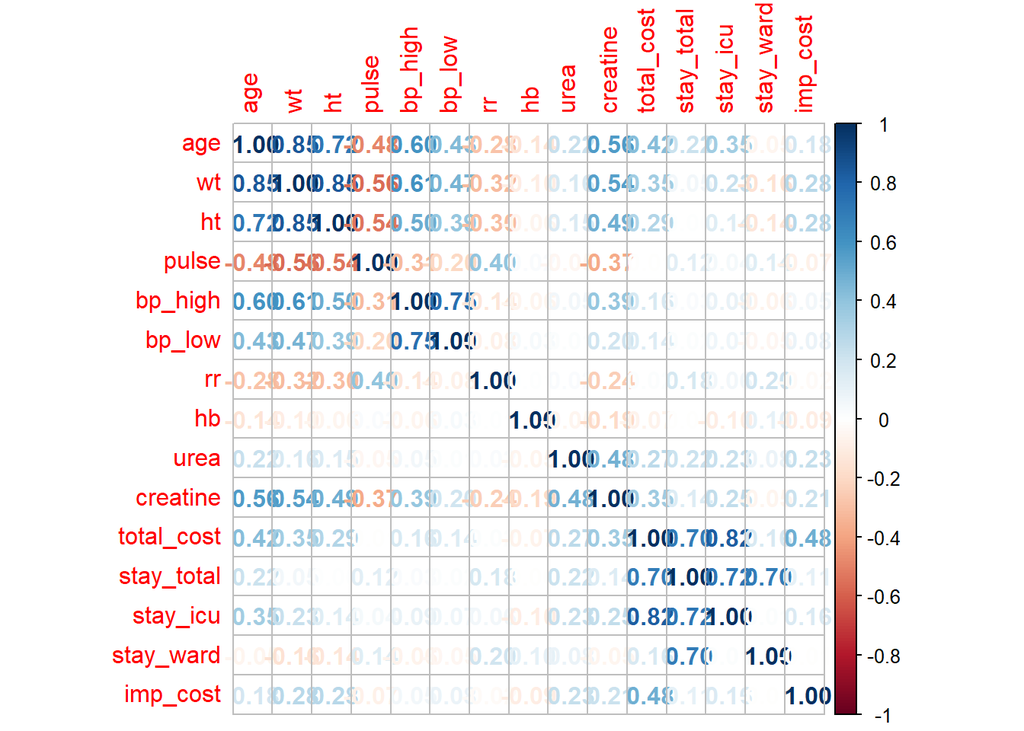

```r
corrplot(correlation, method = "number")
```

```r
highly_correlated <- findCorrelation(correlation, cutoff = 0.7, names = TRUE)

highly_correlated
```

```
## [1] "wt"         "age"        "total_cost" "bp_high"    "stay_icu"
```

## Encoding Categorical Variables

Performing one hot encoding for categorical variables using caret

```r
dummy <- dummyVars("~ .", data = pruned_df, fullRank = T)

encoded_df <- data.frame(predict(dummy, newdata = pruned_df))

summary(encoded_df)
```

```
##       age              gender.M      marital_status.UNMARRIED key_comp.CAD.DVD
##  Min.   : 0.03288   Min.   :0.0000   Min.   :0.0000           Min.   :0.0000
##  1st Qu.: 6.00000   1st Qu.:0.0000   1st Qu.:0.0000           1st Qu.:0.0000
##  Median :15.50000   Median :1.0000   Median :1.0000           Median :0.0000
##  Mean   :28.87984   Mean   :0.6694   Mean   :0.5645           Mean   :0.1573
##  3rd Qu.:55.00000   3rd Qu.:1.0000   3rd Qu.:1.0000           3rd Qu.:0.0000
##  Max.   :88.00000   Max.   :1.0000   Max.   :1.0000           Max.   :1.0000
##  key_comp.CAD.SVD   key_comp.CAD.TVD key_comp.CAD.VSD   key_comp.OS.ASD
##  Min.   :0.000000   Min.   :0.000    Min.   :0.000000   Min.   :0.00000
##  1st Qu.:0.000000   1st Qu.:0.000    1st Qu.:0.000000   1st Qu.:0.00000
##  Median :0.000000   Median :0.000    Median :0.000000   Median :0.00000
##  Mean   :0.008065   Mean   :0.121    Mean   :0.004032   Mean   :0.06452
##  3rd Qu.:0.000000   3rd Qu.:0.000    3rd Qu.:0.000000   3rd Qu.:0.00000
##  Max.   :1.000000   Max.   :1.000    Max.   :1.000000   Max.   :1.00000
##  key_comp.other..heart key_comp.other..respiratory key_comp.other.general
##  Min.   :0.0000        Min.   :0.00000             Min.   :0.000000
##  1st Qu.:0.0000        1st Qu.:0.00000             1st Qu.:0.000000
##  Median :0.0000        Median :0.00000             Median :0.000000
##  Mean   :0.2419        Mean   :0.08065             Mean   :0.004032
##  3rd Qu.:0.0000        3rd Qu.:0.00000             3rd Qu.:0.000000
##  Max.   :1.0000        Max.   :1.00000             Max.   :1.000000
##  key_comp.other.nervous key_comp.other.tertalogy key_comp.PM.VSD
##  Min.   :0.0000         Min.   :0.00000          Min.   :0.00000
##  1st Qu.:0.0000         1st Qu.:0.00000          1st Qu.:0.00000
##  Median :0.0000         Median :0.00000          Median :0.00000
##  Mean   :0.0121         Mean   :0.07661          Mean   :0.02419
##  3rd Qu.:0.0000         3rd Qu.:0.00000          3rd Qu.:0.00000
##  Max.   :1.0000         Max.   :1.00000          Max.   :1.00000
##   key_comp.RHD          wt              ht            pulse
##  Min.   :0.0000   Min.   : 2.02   Min.   : 19.0   Min.   : 41.00
##  1st Qu.:0.0000   1st Qu.:15.00   1st Qu.:105.0   1st Qu.: 78.00
##  Median :0.0000   Median :40.90   Median :147.5   Median : 90.00
##  Mean   :0.1169   Mean   :37.52   Mean   :130.2   Mean   : 92.23
##  3rd Qu.:0.0000   3rd Qu.:58.25   3rd Qu.:160.0   3rd Qu.:104.00
##  Max.   :1.0000   Max.   :85.00   Max.   :185.0   Max.   :155.00
##     bp_high          bp_low             rr              hb
##  Min.   : 70.0   Min.   : 39.00   Min.   :12.00   Min.   : 5.00
##  1st Qu.:100.0   1st Qu.: 60.00   1st Qu.:22.00   1st Qu.:11.28
##  Median :110.0   Median : 70.00   Median :24.00   Median :12.35
##  Mean   :114.3   Mean   : 71.91   Mean   :23.54   Mean   :12.94
```

[output cut: 8 more lines]

```
##  Max.   :143.00   Max.   :5.2000   Max.   :1.00000      Max.   :1.0000
##  adm_type.EMERGENCY   total_cost       stay_total       stay_icu
##  Min.   :0.000      Min.   : 46093   Min.   : 3.00   Min.   : 0.000
##  1st Qu.:0.000      1st Qu.:131653   1st Qu.: 8.00   1st Qu.: 1.000
##  Median :0.000      Median :162661   Median :10.00   Median : 2.000
##  Mean   :0.129      Mean   :198723   Mean   :11.61   Mean   : 3.476
##  3rd Qu.:0.000      3rd Qu.:220614   3rd Qu.:13.00   3rd Qu.: 4.000
##  Max.   :1.000      Max.   :887350   Max.   :41.00   Max.   :30.000
##    stay_ward        imp_used.Y        imp_cost
##  Min.   : 0.000   Min.   :0.0000   Min.   :     0
##  1st Qu.: 6.000   1st Qu.:0.0000   1st Qu.:     0
##  Median : 7.000   Median :0.0000   Median :     0
##  Mean   : 8.153   Mean   :0.1976   Mean   :  8544
##  3rd Qu.:10.000   3rd Qu.:0.0000   3rd Qu.:     0
##  Max.   :22.000   Max.   :1.0000   Max.   :196848
```

```r
str(encoded_df)
```

```
## 'data.frame':    248 obs. of  33 variables:
##  $ age                        : num  58 59 82 46 60 75 73 71 72 61 ...
##  $ gender.M                   : num  1 1 1 1 1 1 1 1 1 1 ...
##  $ marital_status.UNMARRIED   : num  0 0 0 0 0 0 0 0 0 0 ...
##  $ key_comp.CAD.DVD           : num  0 1 0 1 1 1 0 0 1 0 ...
##  $ key_comp.CAD.SVD           : num  0 0 0 0 0 0 0 0 0 0 ...
##  $ key_comp.CAD.TVD           : num  0 0 1 0 0 0 1 1 0 1 ...
##  $ key_comp.CAD.VSD           : num  0 0 0 0 0 0 0 0 0 0 ...
##  $ key_comp.OS.ASD            : num  0 0 0 0 0 0 0 0 0 0 ...
##  $ key_comp.other..heart      : num  1 0 0 0 0 0 0 0 0 0 ...
##  $ key_comp.other..respiratory: num  0 0 0 0 0 0 0 0 0 0 ...
##  $ key_comp.other.general     : num  0 0 0 0 0 0 0 0 0 0 ...
##  $ key_comp.other.nervous     : num  0 0 0 0 0 0 0 0 0 0 ...
##  $ key_comp.other.tertalogy   : num  0 0 0 0 0 0 0 0 0 0 ...
##  $ key_comp.PM.VSD            : num  0 0 0 0 0 0 0 0 0 0 ...
```

[output cut: 19 more lines]

## Splitting data into Train and Test

```r
set.seed(1904)

index <- sample(1:nrow(encoded_df), .80*nrow(encoded_df))

train <- encoded_df[index,]

test <- encoded_df[-index,]
```

# Building Predictive Models

## Building a Linear Regression Model

```r
set.seed(1904)

options (scipen = 100)

linear_model <- lm(total_cost ~ ., data = train)

summary(linear_model)
```

```
##
## Call:
## lm(formula = total_cost ~ ., data = train)
##
## Residuals:
##     Min      1Q  Median      3Q     Max
## -148537  -21949    -975   13840  375102
##
## Coefficients:
##                                Estimate  Std. Error t value       Pr(>|t|)
## (Intercept)                  -4579.8023  72659.3548  -0.063         0.9498
## age                              2.7599    406.3032   0.007         0.9946
## gender.M                      1865.2365   8574.1414   0.218         0.8281
## marital_status.UNMARRIED     -4057.6562  18369.4985  -0.221         0.8255
## key_comp.CAD.DVD             -4134.0520  19467.6343  -0.212         0.8321
## key_comp.CAD.SVD             33770.3715  40359.7008   0.837         0.4040
## key_comp.CAD.TVD             17504.0158  19921.5137   0.879         0.3809
## key_comp.CAD.VSD             29680.8091  51983.7400   0.571         0.5688
## key_comp.OS.ASD              11346.5363  19965.5960   0.568         0.5706
## key_comp.other..heart        -8734.9087  15198.9780  -0.575         0.5663
## key_comp.other..respiratory   -111.1913  18560.8550  -0.006         0.9952
## key_comp.other.general      -73878.5065  58188.4070  -1.270         0.2060
## key_comp.other.nervous       -7474.7389  32463.4450  -0.230         0.8182
## key_comp.other.tertalogy     28195.5053  19712.0300   1.430         0.1545
## key_comp.PM.VSD              31576.8807  27588.3223   1.145         0.2540
## key_comp.RHD                 -4345.4373  19302.9205  -0.225         0.8222
## wt                            -263.1056    473.4871  -0.556         0.5792
## ht                             334.2512    191.0318   1.750         0.0820 .
## pulse                          450.9114    239.4463   1.883         0.0614 .
## bp_high                         11.8119    304.5460   0.039         0.9691
## bp_low                         341.9899    408.1846   0.838         0.4033
## rr                           -1177.6136   1094.9139  -1.076         0.2837
## hb                             614.6325   1370.6730   0.448         0.6544
## urea                          -341.6116    329.8413  -1.036         0.3019
## creatine                     28608.8254  14818.9679   1.931         0.0553 .
## arr_mode.TRANSFERRED        -54980.8073  48784.4942  -1.127         0.2614
## arr_mode.WALKED.IN          -39547.0569  39135.2263  -1.011         0.3137
## adm_type.EMERGENCY          -52900.7427  38032.6771  -1.391         0.1661
## stay_total                    4625.3225  18930.7112   0.244         0.8073
## stay_icu                     21945.7740  18948.8366   1.158         0.2485
## stay_ward                      630.8377  18802.4875   0.034         0.9733
## imp_used.Y                    3390.9455  16832.6005   0.201         0.8406
## imp_cost                         1.9088      0.2853   6.690 0.000000000331 ***
## ---
## Signif. codes:  0 '***' 0.001 '**' 0.01 '*' 0.05 '.' 0.1 ' ' 1
##
## Residual standard error: 49680 on 165 degrees of freedom
## Multiple R-squared:  0.877,  Adjusted R-squared:  0.8532
## F-statistic: 36.77 on 32 and 165 DF,  p-value: < 0.00000000000000022
```

### Performing a multi-collinearity check on the linear model

```r
vif(linear_model)
```

```
##                         age                    gender.M
##                    9.136732                    1.290363
##    marital_status.UNMARRIED            key_comp.CAD.DVD
##                    6.734945                    4.425148
##            key_comp.CAD.SVD            key_comp.CAD.TVD
##                    1.306856                    3.632388
##            key_comp.CAD.VSD             key_comp.OS.ASD
##                    1.089550                    1.820977
##       key_comp.other..heart key_comp.other..respiratory
##                    3.151191                    2.053209
##      key_comp.other.general      key_comp.other.nervous
##                    1.365164                    1.261801
##    key_comp.other.tertalogy             key_comp.PM.VSD
##                    2.182985                    1.503224
##                key_comp.RHD                          wt
##                    3.069430                    9.454961
##                          ht                       pulse
##                    4.543775                    1.839008
##                     bp_high                      bp_low
##                    3.726929                    2.962276
##                          rr                          hb
##                    1.536719                    1.353213
##                        urea                    creatine
##                    2.473583                    3.746078
##        arr_mode.TRANSFERRED          arr_mode.WALKED.IN
##                    2.849478                   16.227799
##          adm_type.EMERGENCY                  stay_total
##                   14.920731                  866.152208
##                    stay_icu                   stay_ward
##                  398.282223                  408.980990
##                  imp_used.Y                    imp_cost
##                    3.525752                    3.138102
```

## Building another model leaving out variables with high VIF values.

```r
set.seed(1904)

linear_model2 <- lm(total_cost ~ age + gender.M + marital_status.UNMARRIED + key_comp.CAD.DVD +
                      key_comp.CAD.SVD  + key_comp.CAD.TVD + key_comp.CAD.VSD + key_comp.OS.ASD +
                      key_comp.other..heart + key_comp.other..respiratory + key_comp.other.general +
                      key_comp.other.nervous + key_comp.other.tertalogy + key_comp.PM.VSD + key_comp.RHD +
                      ht + pulse + bp_high + bp_low + rr + hb + urea + creatine + arr_mode.TRANSFERRED +
                      imp_used.Y + imp_cost + stay_icu, data = train)

summary(linear_model2)
```

```
##
## Call:
## lm(formula = total_cost ~ age + gender.M + marital_status.UNMARRIED +
##     key_comp.CAD.DVD + key_comp.CAD.SVD + key_comp.CAD.TVD +
##     key_comp.CAD.VSD + key_comp.OS.ASD + key_comp.other..heart +
##     key_comp.other..respiratory + key_comp.other.general + key_comp.other.nervous +
##     key_comp.other.tertalogy + key_comp.PM.VSD + key_comp.RHD +
##     ht + pulse + bp_high + bp_low + rr + hb + urea + creatine +
##     arr_mode.TRANSFERRED + imp_used.Y + imp_cost + stay_icu,
##     data = train)
##
## Residuals:
##     Min      1Q  Median      3Q     Max
## -190320  -22422   -1794   16895  346022
##
## Coefficients:
##                                 Estimate   Std. Error t value
## (Intercept)                  -27055.4303   54274.8948  -0.498
## age                              23.5284     418.0343   0.056
## gender.M                       6427.4182    8985.6176   0.715
## marital_status.UNMARRIED      -1695.5307   18201.1347  -0.093
## key_comp.CAD.DVD               -408.6392   20482.8133  -0.020
## key_comp.CAD.SVD              72708.4475   41941.8672   1.734
## key_comp.CAD.TVD              11207.6098   20722.5238   0.541
## key_comp.CAD.VSD              43784.8717   55269.4737   0.792
## key_comp.OS.ASD               17575.7080   20983.2736   0.838
## key_comp.other..heart         -2145.9533   16123.1511  -0.133
## key_comp.other..respiratory   -4687.0958   19680.7504  -0.238
## key_comp.other.general      -105351.4547   61162.7729  -1.722
## key_comp.other.nervous        -7124.5643   34568.8881  -0.206
## key_comp.other.tertalogy      31870.5764   20931.2965   1.523
## key_comp.PM.VSD               19383.9852   29164.7204   0.665
## key_comp.RHD                   3130.3883   20313.1788   0.154
## ht                              172.6552     168.7057   1.023
## pulse                           600.0117     248.9274   2.410
## bp_high                          19.8301     319.3257   0.062
## bp_low                          183.6752     427.8611   0.429
## rr                             -509.4859    1128.4542  -0.451
## hb                             1189.7778    1444.7458   0.824
## urea                           -247.5464     339.3710  -0.729
```

[output cut: 25 more lines]

```
## bp_low                                    0.6683
## rr                                        0.6522
## hb                                        0.4114
## urea                                      0.4667
## creatine                                  0.0779 .
## arr_mode.TRANSFERRED                      0.9190
## imp_used.Y                                0.5821
## imp_cost                           0.00000000861 ***
## stay_icu                    < 0.0000000000000002 ***
## ---
## Signif. codes:  0 '***' 0.001 '**' 0.01 '*' 0.05 '.' 0.1 ' ' 1
##
## Residual standard error: 52930 on 170 degrees of freedom
## Multiple R-squared:  0.8562, Adjusted R-squared:  0.8333
## F-statistic: 37.48 on 27 and 170 DF,  p-value: < 0.00000000000000022
```

### Performing a multi-collinearity check on the second linear model

```r
vif(linear_model2)
```

```
##                         age                    gender.M
##                    8.520283                    1.248435
##    marital_status.UNMARRIED            key_comp.CAD.DVD
##                    5.824733                    4.315392
##            key_comp.CAD.SVD            key_comp.CAD.TVD
##                    1.243274                    3.462362
##            key_comp.CAD.VSD             key_comp.OS.ASD
##                    1.084981                    1.771846
##       key_comp.other..heart key_comp.other..respiratory
##                    3.123816                    2.033574
##      key_comp.other.general      key_comp.other.nervous
##                    1.328697                    1.260411
##    key_comp.other.tertalogy             key_comp.PM.VSD
##                    2.168303                    1.479886
##                key_comp.RHD                          ht
##                    2.994381                    3.121795
##                       pulse                     bp_high
##                    1.750865                    3.609548
##                      bp_low                          rr
##                    2.867198                    1.437944
##                          hb                        urea
##                    1.324405                    2.306777
##                    creatine        arr_mode.TRANSFERRED
##                    3.632424                    1.182002
##                  imp_used.Y                    imp_cost
##                    3.414249                    2.900460
##                    stay_icu
##                    1.801676
```

## Using `linear_model2` for prediction on the Test data

```r
lm_prediction <- predict(linear_model2, newdata = test)

test$lm_prediction <- lm_prediction
```

### Checking Model accuracy with RMSE and MAPE tests

```r
mape_lm <- mape(test$total_cost, test$lm_prediction)
mape_lm
```

```
## [1] 0.1985779
```

```r
rmse_lm <- rmse(test$total_cost, test$lm_prediction)
rmse_lm
```

```
## [1] 58547.15
```

```r
lm_accuracy <- data.frame(
  MAPE = mape_lm,
  RMSE = rmse_lm
)

lm_accuracy
```

```
##        MAPE     RMSE
## 1 0.1985779 58547.15
```

The Test data prediction using `linear_model2` has 80% accuracy and RMSE value of over 58K.

## Bulding a Decision Tree Model

```r
set.seed(1904)

dt_model <- rpart(total_cost ~ ., data = train, method = "anova")

summary(dt_model)
```

```
## Call:
## rpart(formula = total_cost ~ ., data = train, method = "anova")
##   n= 198
##
##           CP nsplit rel error    xerror       xstd
## 1 0.62566305      0 1.0000000 1.0143923 0.22013186
## 2 0.05663074      1 0.3743370 0.3896188 0.07563868
## 3 0.04955853      2 0.3177062 0.4210170 0.08441654
## 4 0.03624402      3 0.2681477 0.4007783 0.09937761
## 5 0.01085274      4 0.2319037 0.4003592 0.09779834
## 6 0.01000000      5 0.2210509 0.3933931 0.09736461
##
## Variable importance
##   stay_icu stay_total  stay_ward   creatine   imp_cost        age         rr
##         49         21          9          5          4          4          3
## imp_used.Y         hb       urea    bp_high
##          2          1          1          1
##
## Node number 1: 198 observations,    complexity param=0.625663
##   mean=202277.2, MSE=1.672096e+10
##   left son=2 (173 obs) right son=3 (25 obs)
##   Primary splits:
##       stay_icu   < 8.5   to the left,  improve=0.6256630, (0 missing)
##       stay_total < 13.5  to the left,  improve=0.3595201, (0 missing)
##       imp_cost   < 34435 to the left,  improve=0.2110877, (0 missing)
##       creatine   < 1.35  to the left,  improve=0.1916241, (0 missing)
##       age        < 39.5  to the left,  improve=0.1806799, (0 missing)
##   Surrogate splits:
##       stay_total < 20.5  to the left,  agree=0.929, adj=0.44, (0 split)
##       stay_ward  < 1.5   to the right, agree=0.894, adj=0.16, (0 split)
##       creatine   < 1.35  to the left,  agree=0.889, adj=0.12, (0 split)
##       age        < 74.5  to the left,  agree=0.884, adj=0.08, (0 split)
##       rr         < 33    to the left,  agree=0.884, adj=0.08, (0 split)
##
## Node number 2: 173 observations,    complexity param=0.05663074
##   mean=163395.2, MSE=3.722551e+09
##   left son=4 (152 obs) right son=5 (21 obs)
##   Primary splits:
##       imp_cost   < 23749 to the left,  improve=0.2911332, (0 missing)
##       stay_icu   < 3.5   to the left,  improve=0.2733380, (0 missing)
```

[output cut: 59 more lines]

```
##   Surrogate splits:
##       stay_ward < 8.5   to the left,  agree=0.944, adj=0.837, (0 split)
##       hb        < 15.95 to the left,  agree=0.694, adj=0.116, (0 split)
##       wt        < 12.75 to the right, agree=0.685, adj=0.093, (0 split)
##       urea      < 15.5  to the right, agree=0.685, adj=0.093, (0 split)
##       ht        < 37    to the right, agree=0.677, adj=0.070, (0 split)
##
## Node number 9: 28 observations
##   mean=220299.3, MSE=2.409342e+09
##
## Node number 16: 81 observations
##   mean=123143.8, MSE=9.467567e+08
##
## Node number 17: 43 observations
##   mean=158909.5, MSE=1.203154e+09
```

### Presenting a graphical representation of `dt_model`.

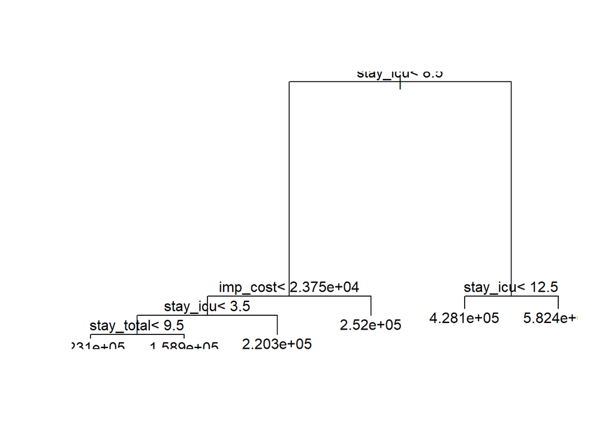

```r
plot(dt_model)
text(dt_model)
```

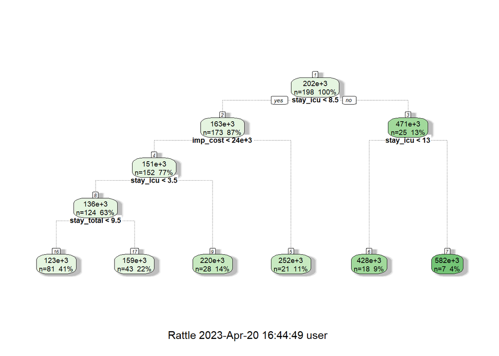

```r
fancyRpartPlot(dt_model, cex = .60)
```

## Using `dt_model` for prediction on the Test data.

```r
dt_prediction <- predict(dt_model, newdata = test, type = "vector")

test$dt_prediction <- dt_prediction
```

### Checking Model accuracy with RMSE and MAPE tests.

```r
mape_dt <- mape(test$total_cost, test$dt_prediction)
mape_dt
```

```
## [1] 0.2031114
```

```r
rmse_dt <- rmse(test$total_cost, test$dt_prediction)
rmse_dt
```

```
## [1] 44076.66
```

```r
dt_accuracy <- data.frame(
  MAPE = mape_dt,
  RMSE = rmse_dt
)

dt_accuracy
```

```
##        MAPE     RMSE
## 1 0.2031114 44076.66
```

The Test data prediction using `dt_model` has just over 79% accuracy and a RMSE value of just over 44K.

## Building a Random Forest Model

```r
set.seed(1904)

rf_model <- randomForest(total_cost ~ ., data = train)

print(rf_model)
```

```
##
## Call:
##  randomForest(formula = total_cost ~ ., data = train)
##                Type of random forest: regression
##                      Number of trees: 500
## No. of variables tried at each split: 10
##
##           Mean of squared residuals: 4489143842
##                     % Var explained: 73.15
```

The `rf_model` is able to explain 73% variance in the model and considers 10 variables at each split.

### Identifying the most significant variables in `rf_model`.

```r
importance(rf_model)
```

```
##                             IncNodePurity
## age                          143966209241
## gender.M                       5923177603
## marital_status.UNMARRIED      17286209867
## key_comp.CAD.DVD              10846649045
## key_comp.CAD.SVD               4611988830
## key_comp.CAD.TVD               7665095504
## key_comp.CAD.VSD                 26864275
## key_comp.OS.ASD                 514219896
## key_comp.other..heart         10469285254
## key_comp.other..respiratory    1252703936
## key_comp.other.general         1441207106
## key_comp.other.nervous          656795112
## key_comp.other.tertalogy       2536289605
## key_comp.PM.VSD                 244390498
## key_comp.RHD                   6535545944
## wt                           105071947326
## ht                            97044801312
## pulse                         64813441214
## bp_high                       70671274763
## bp_low                        31590974467
## rr                            33841125518
## hb                            53982953084
## urea                          81882647578
## creatine                     128680980037
## arr_mode.TRANSFERRED            239345265
## arr_mode.WALKED.IN            23367093140
## adm_type.EMERGENCY            31752538539
## stay_total                   586286607446
## stay_icu                    1122891737596
## stay_ward                    194629685055
## imp_used.Y                    97611357461
## imp_cost                     251604694492
```

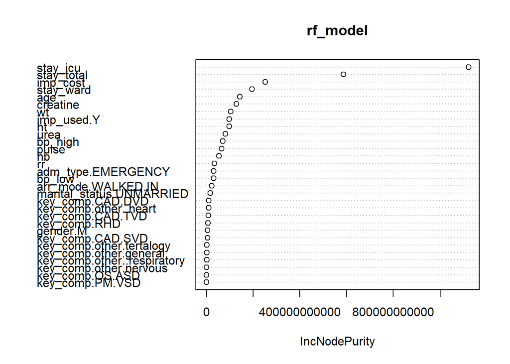

```r
varImpPlot(rf_model)
```

The `rf_model` identifies the length of stay and in particular the length of stay in ICU as the most important variables impacting cost.

## Tuning parameters to check the optimal mtry value

```
## mtry = 10  OOB error = 4350049921
## Searching left ...
## mtry = 5     OOB error = 5242934257
## -0.2052584 0.05
## Searching right ...
## mtry = 20    OOB error = 4380104764
## -0.00690908 0.05
```

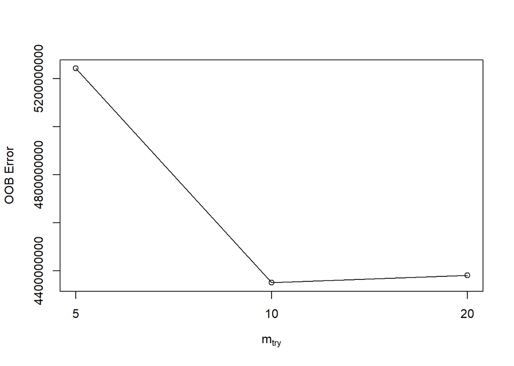

```
##    mtry   OOBError
## 5     5 5242934257
## 10   10 4350049921
## 20   20 4380104764
```

```r
set.seed(2004)

tuneRF(train[, -28], train[, 28], stepFactor = 2, plot = T, ntreeTry = 500, improve = .05)
```

```
## mtry = 10  OOB error = 4369788493
## Searching left ...
## mtry = 5     OOB error = 5148336877
## -0.1781661 0.05
## Searching right ...
## mtry = 20    OOB error = 4429180521
## -0.01359151 0.05
```

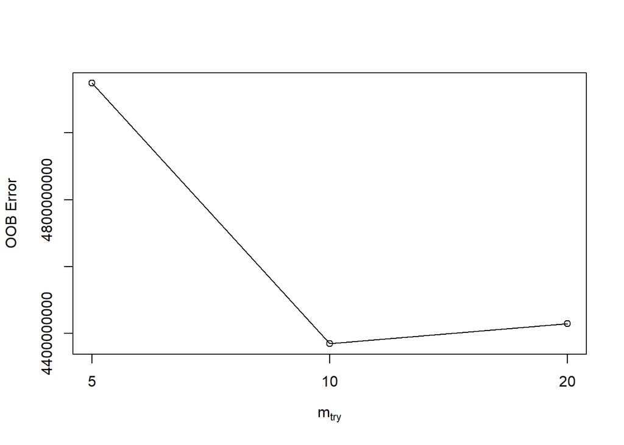

```
##    mtry   OOBError
## 5     5 5148336877
## 10   10 4369788493
## 20   20 4429180521
```

```r
tuneRF(train[, -28], train[, 28], stepFactor = 2, plot = T, ntreeTry = 1000, improve = .05)
```

Parameter tuning with ntree at 500 and 1000 find 10 to be the optimal mtry. As the `rf_model` already has a mtry of 10, proceeding with this model for prediction.

## Using the `rf_model` for prediction on Test data.

```r
rf_prediction <- predict(rf_model, newdata = test, type = "response")

test$rf_prediction <- rf_prediction
```

### Checking Model accuracy with RMSE and MAPE tests.

```r
mape_rf <- mape(test$total_cost, test$rf_prediction)
mape_rf
```

```
## [1] 0.1687929
```

```r
rmse_rf <- rmse(test$total_cost, test$rf_prediction)
rmse_rf
```

```
## [1] 41161.85
```

```r
rf_accuracy <- data.frame(
  MAPE = mape_rf,
  RMSE = rmse_rf
)

rf_accuracy
```

```
##        MAPE     RMSE
## 1 0.1687929 41161.85
```

The `rf_model` has a 83% accuracy and an RMSE value of just over 41K.

# Model Accuracy Comparison

Comparing all the 3 predictive model to determine the best model for Mission Hospital

```r
accuracy_comparison <- data.frame(
  Model = c("Random Forest", "Decision Tree", "Linear Regression"),
  MAPE = c(mape_rf, mape_dt, mape_lm),
  RMSE = c(rmse_rf, rmse_dt, rmse_lm)
)

accuracy_comparison
```

```
##               Model      MAPE     RMSE
## 1     Random Forest 0.1687929 41161.85
## 2     Decision Tree 0.2031114 44076.66
## 3 Linear Regression 0.1985779 58547.15
```

Of the 3 predictive models, the Random Forest model was found to be the most accurate with the lowest error margin. The analyst will recommend this model for price prediction for Mission Hospital.